# Weight Lifting Analysis

Alex Fennell

# Synopsis

The goal of this project is to correctly classify the quality of physical activity an individual carried out based on accelerometer collected from the belt, forearm, arm, and dumbell. There were 5 different ways in which the exercise was carried out. It was done either exactly according to the specification (Class A), throwing the elbows to the front (Class B), lifting the dumbbell only halfway (Class C), lowering the dumbbell only halfway (Class D) and throwing the hips to the front (Class E). Class A is the correct manner in which the exercise should be carried out, while the other classes are common errors. Using the accelerometer data I was able to create a random forest model that classified this inoformation into the 5 desired classes with 98 percent accuracy.

```r
library(Hmisc)
library(vip)
library(dplyr)
library(randomForest)
library(e1071)
library(parallel)
library(MLmetrics)
library(foreach)
library(doParallel)
library(caret)
```

# Read in the Data

```r
#train data location
fileurl<-"https://d396qusza40orc.cloudfront.net/predmachlearn/pml-training.csv"
if (!file.exists("fittrain.csv")){
    download.file(fileurl,"fittrain.csv",method="curl")
}
#test data location
fileurl<-"https://d396qusza40orc.cloudfront.net/predmachlearn/pml-testing.csv"
if (!file.exists("fittest.csv")){
    download.file(fileurl,"fittest.csv",method="curl")
}

# The data sets had many entries that were spaces ("") and thus I specified these
# to be missing values (NA)
fit_train<-read.csv("fittrain.csv",na.strings = c("NA",""))
fit_test<-read.csv("fittest.csv",na.strings = c("NA",""))
```

# Assessing missing data

The first thing I want to do is assess the amount of missing data, so I know if there are certain predictors I should remove, or I should implement an imputation technique.

```r
colSums(is.na(fit_train))
```

```
##                        X                user_name     raw_timestamp_part_1
##                        0                        0                        0
##     raw_timestamp_part_2           cvtd_timestamp               new_window
##                        0                        0                        0
##               num_window                roll_belt               pitch_belt
##                        0                        0                        0
##                 yaw_belt         total_accel_belt       kurtosis_roll_belt
##                        0                        0                    19216
##      kurtosis_picth_belt        kurtosis_yaw_belt       skewness_roll_belt
##                    19216                    19216                    19216
##     skewness_roll_belt.1        skewness_yaw_belt            max_roll_belt
##                    19216                    19216                    19216
##           max_picth_belt             max_yaw_belt            min_roll_belt
##                    19216                    19216                    19216
##           min_pitch_belt             min_yaw_belt      amplitude_roll_belt
##                    19216                    19216                    19216
##     amplitude_pitch_belt       amplitude_yaw_belt     var_total_accel_belt
##                    19216                    19216                    19216
##            avg_roll_belt         stddev_roll_belt            var_roll_belt
##                    19216                    19216                    19216
##           avg_pitch_belt        stddev_pitch_belt           var_pitch_belt
##                    19216                    19216                    19216
##             avg_yaw_belt          stddev_yaw_belt             var_yaw_belt
##                    19216                    19216                    19216
##             gyros_belt_x             gyros_belt_y             gyros_belt_z
##                        0                        0                        0
##             accel_belt_x             accel_belt_y             accel_belt_z
##                        0                        0                        0
##            magnet_belt_x            magnet_belt_y            magnet_belt_z
##                        0                        0                        0
##                 roll_arm                pitch_arm                  yaw_arm
##                        0                        0                        0
##          total_accel_arm            var_accel_arm             avg_roll_arm
##                        0                    19216                    19216
##          stddev_roll_arm             var_roll_arm            avg_pitch_arm
##                    19216                    19216                    19216
##         stddev_pitch_arm            var_pitch_arm              avg_yaw_arm
##                    19216                    19216                    19216
##           stddev_yaw_arm              var_yaw_arm              gyros_arm_x
##                    19216                    19216                        0
```

[output cut: 53 more lines]

```
##                    19216                        0                    19216
##         avg_roll_forearm      stddev_roll_forearm         var_roll_forearm
##                    19216                    19216                    19216
##        avg_pitch_forearm     stddev_pitch_forearm        var_pitch_forearm
##                    19216                    19216                    19216
##          avg_yaw_forearm       stddev_yaw_forearm          var_yaw_forearm
##                    19216                    19216                    19216
##          gyros_forearm_x          gyros_forearm_y          gyros_forearm_z
##                        0                        0                        0
##          accel_forearm_x          accel_forearm_y          accel_forearm_z
##                        0                        0                        0
##         magnet_forearm_x         magnet_forearm_y         magnet_forearm_z
##                        0                        0                        0
##                   classe
##                        0
```

Given a good number of these predictors are columns of missing values, I will go ahead and remove any predictor that is more than 95% missing values.

## Removing Missing Values

```r
threshold=.95
trainfilt<-fit_train[,colSums(is.na(fit_train))<(nrow(fit_train)*threshold)]
testfilt<-fit_test[,colSums(is.na(fit_test))<(nrow(fit_test)*threshold)]
```

## Keeping accelerometer data

I am only interested in data from the accelerometers, so I will remove columns that contain other information.

```r
trainfilt<-trainfilt[,-c(1,2,3,4,5,6,7)]
testfilt<-testfilt[,-c(1,2,3,4,5,6,7)]

trainfilt$classe<-as.factor(trainfilt$classe)
```

## Correlated Predictors

The next step in understanding the data is to look at correlations among the predictors. If variables are highly related to each other, it may be worthwhile to remove them or do some dimensionality reduction such as PCA. I use a correlation of .75 here so as to only examine the most highly correlated predictors.

```r
cormat<-trainfilt%>%
    select_if(is.numeric)%>%
    as.matrix()%>%
    rcorr(type='spearman')
highcor<-findCorrelation(cormat$r,cutoff = 0.75)
colnames(cormat$r[highcor,highcor])
```

```
##  [1] "accel_belt_z"     "accel_dumbbell_z" "accel_belt_y"     "yaw_belt"
##  [5] "accel_dumbbell_y" "roll_belt"        "magnet_belt_x"    "pitch_belt"
##  [9] "accel_dumbbell_x" "magnet_belt_y"    "accel_arm_x"      "magnet_arm_y"
## [13] "gyros_arm_x"
```

It is not surprising that there are many correlated predictors given that these are complex movements that require coordination from many parts of the body. Given this, it seems inappropriate to remove variables. Therefore I will go forward with a PCA technique in order to reduce the dimensionality of the data while still retaining the most informative aspects of the data.

## Near Zero Variance

Next I will examine the data set to determine if there are any uniformative predictors and remove them if that is the case.

```r
nsv<-nearZeroVar(trainfilt,saveMetrics = TRUE)
data.frame(zeroVar=sum(nsv$zeroVar==TRUE), NSV=sum(nsv$nzv==TRUE))
```

```
##   zeroVar NSV
## 1       0   0
```

There are no uniformative predictors, so the data is ready for modelling.

## Validation data split

Before modelling, I split the training data set to include a validation set so the model does not overfit.

```r
samp<-createDataPartition(y=trainfilt$classe,p=.8,list = FALSE)
training<-trainfilt[samp,]
validation<-trainfilt[-samp,]
```

# Model analysis

The model I am going to use is a random forest model since these typically have superior performance when it comes to classification. I am using a repeated cross validation procedure with 10 folds, and 3 repeats to get a stable model that minimizes overtraining. I will do a grid search to find the optimal value for the mtry parameter. This parameter corresponds to the number of variables randomly sampled as candidates at each split. I center and scale all the predictors and then do a pca selecting the components that account for 95% of the variance. I use a tree size of 250 as this is enough to produce stable accuracy and is not overly computationally intensive. Model performance will be assessed on its out of sample error rate which is equivalent to 1-Accuracy.

```r
control<-trainControl(method='repeatedcv',
                      number=10,
                      repeats = 3,
                      classProbs = TRUE,
                      summaryFunction = multiClassSummary,
                      allowParallel = TRUE,
                      savePredictions = TRUE,
                      search='grid',
                      verboseIter = TRUE)
tunevals<-expand.grid(.mtry=c(1:10))
#preprocess all datasets
trainpre<-preProcess(training,method=c('center','scale','pca'),thresh=.95)
trainpca<-predict(trainpre,training)
valpca<-predict(trainpre,validation)
testpca<-predict(trainpre,testfilt)

#Parellelize the random forest process
cluster<-makeCluster(detectCores()-6)
registerDoParallel(cluster)
set.seed(1234)
    rfmod<-train(classe~.,
                 data=trainpca,
                 method='rf',
                 ntree=250,
                 tuneGrid=tunevals,
                 verbose=TRUE,
                 metric='Accuracy',
                 trControl=control)
stopCluster(cluster)
registerDoSEQ()
```

## Optimal mtry

This plot shows how the mtry value affects the cross validation accuracy for the model.

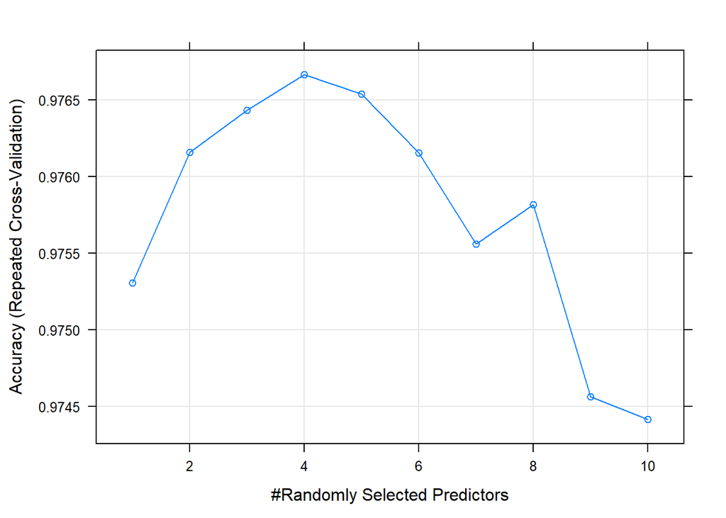

```r
plot(rfmod)
```

This plot shows that an mtry value of 4 results in the highest accuracy on the held out cross validation sets.

# Variable Importance

Using the vip plot we can assess what the most valuable predictors are.

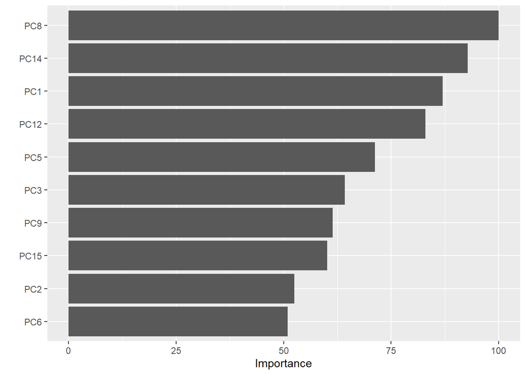

```r
vip(rfmod)
```

The most important predictor appears to be PC8, so let’s examine that to see what this component is capturing.

## Principal Component Analysis

```r
a<-head(sort(trainpre$rotation[,8]),5)
b<-head(sort(trainpre$rotation[,8],decreasing=TRUE),5)
data.frame(PCAmag=c(a,b))
```

```
##                          PCAmag
## magnet_forearm_x    -0.38499830
## total_accel_arm     -0.34414566
## accel_forearm_x     -0.28110644
## total_accel_belt    -0.09798735
## roll_belt           -0.08824928
## roll_dumbbell        0.28073677
## pitch_forearm        0.26813957
## accel_arm_z          0.26730355
## pitch_dumbbell       0.25404497
## total_accel_forearm  0.24877752
```

# Model Fit Evaluation

## Confusion matrix-caret cross validation data set

To assess the model fit I will be using confusion matrices. First I will examine the model fit to the held out resamples in the caret cross validation procedure. Then I will examine the model performance against the validation set that I set aside before beginning the modelling.

```r
confusionMatrix(rfmod)
```

```
## Cross-Validated (10 fold, repeated 3 times) Confusion Matrix
##
## (entries are percentual average cell counts across resamples)
##
##           Reference
## Prediction    A    B    C    D    E
##          A 28.2  0.3  0.0  0.0  0.0
##          B  0.1 18.7  0.3  0.0  0.1
##          C  0.1  0.2 16.9  0.6  0.1
##          D  0.0  0.0  0.2 15.7  0.1
##          E  0.0  0.0  0.0  0.0 18.1
##
##  Accuracy (average) : 0.9767
```

On the cross validation set within the caret procedure, the model is quite accurate with few observations off the diagonals.

## Confusion matrix-validation data set

```r
confusionMatrix(predict(rfmod,valpca),valpca$classe)
```

```
## Confusion Matrix and Statistics
##
##           Reference
## Prediction    A    B    C    D    E
##          A 1108    9    1    1    0
##          B    3  741   14    0    5
##          C    3    6  663   27    2
##          D    2    0    6  615    0
##          E    0    3    0    0  714
##
## Overall Statistics
##
##                Accuracy : 0.9791
##                  95% CI : (0.9741, 0.9833)
##     No Information Rate : 0.2845
##     P-Value [Acc > NIR] : < 2.2e-16
##
##                   Kappa : 0.9736
##
##  Mcnemar's Test P-Value : NA
##
## Statistics by Class:
##
##                      Class: A Class: B Class: C Class: D Class: E
## Sensitivity            0.9928   0.9763   0.9693   0.9565   0.9903
## Specificity            0.9961   0.9930   0.9883   0.9976   0.9991
## Pos Pred Value         0.9902   0.9712   0.9458   0.9872   0.9958
## Neg Pred Value         0.9971   0.9943   0.9935   0.9915   0.9978
## Prevalence             0.2845   0.1935   0.1744   0.1639   0.1838
## Detection Rate         0.2824   0.1889   0.1690   0.1568   0.1820
## Detection Prevalence   0.2852   0.1945   0.1787   0.1588   0.1828
## Balanced Accuracy      0.9945   0.9847   0.9788   0.9770   0.9947
```

# Conclusion

With the validation set the model performs very well with an accuracy of ~98%. Thus the model has an out of sample error of 2 percent. Thus, with the test data set the model should make 0 or maybe 1 error given there are 20 samples in the test set. This model seems to do an excellent job of classifying the quality of an exercise based on accelerometer data.

The predicted values for the test set are presented below. These were all correct as indicated by the quiz results.

```r
rfpred<-predict(rfmod,testpca)
rfpred
```

```
##  [1] B A A A A E D B A A A C B A E E A B B B
## Levels: A B C D E
```